# turtle_path_01

A turtle starts at the star in the middle. By dragging markers along a grid, she makes 5 line segments. The first segment is red, and then she changes color after each turn, following the progression of a rainbow.

The distance between adjacent dots is 1 unit. The grid is oriented with North pointing up and East pointing right.

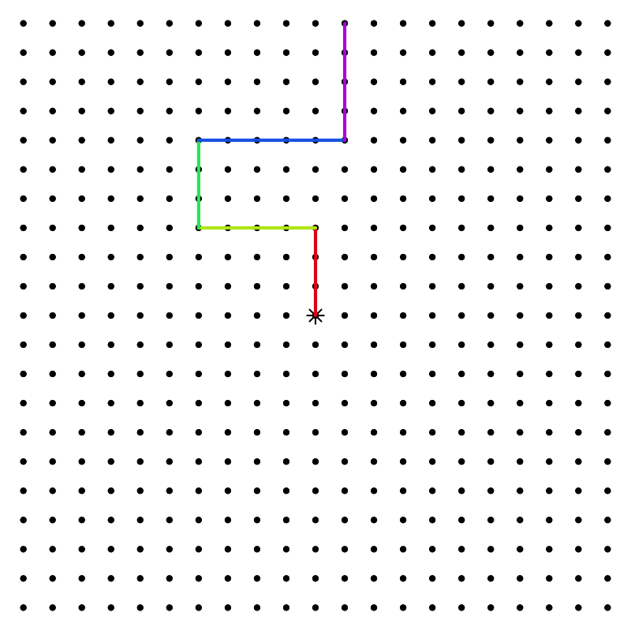

Describe the path taken by the turtle.

- North 3
- West 4
- North 3
- East 5
- North 4

A turtle starts at the star in the middle. By dragging markers along a grid, she makes 5 line segments. The first segment is red, and then she changes color after each turn, following the progression of a rainbow.

The distance between adjacent dots is 1 unit. The grid is oriented with North pointing up and East pointing right.

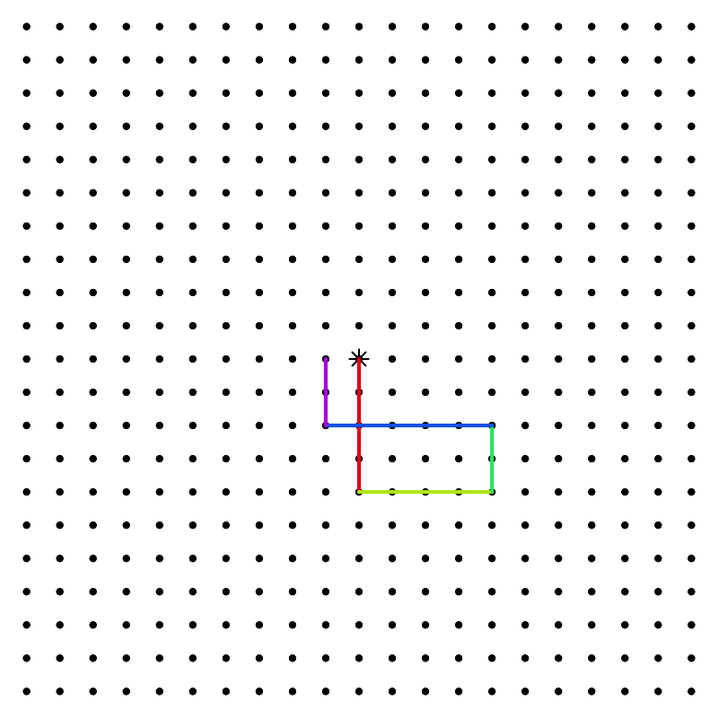

Describe the path taken by the turtle.

- South 4
- East 4
- North 2
- West 5
- North 2

A turtle starts at the star in the middle. By dragging markers along a grid, she makes 5 line segments. The first segment is red, and then she changes color after each turn, following the progression of a rainbow.

The distance between adjacent dots is 1 unit. The grid is oriented with North pointing up and East pointing right.

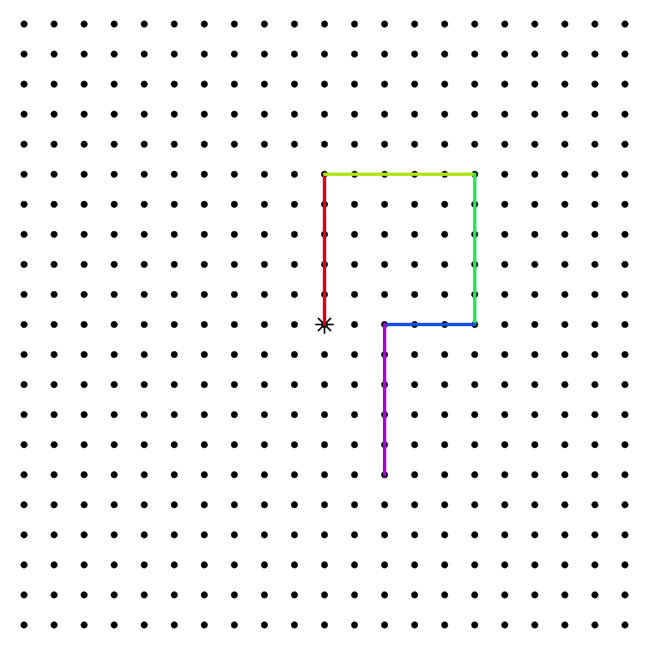

Describe the path taken by the turtle.

- North 5
- East 5
- South 5
- West 3
- South 5

A turtle starts at the star in the middle. By dragging markers along a grid, she makes 5 line segments. The first segment is red, and then she changes color after each turn, following the progression of a rainbow.

The distance between adjacent dots is 1 unit. The grid is oriented with North pointing up and East pointing right.

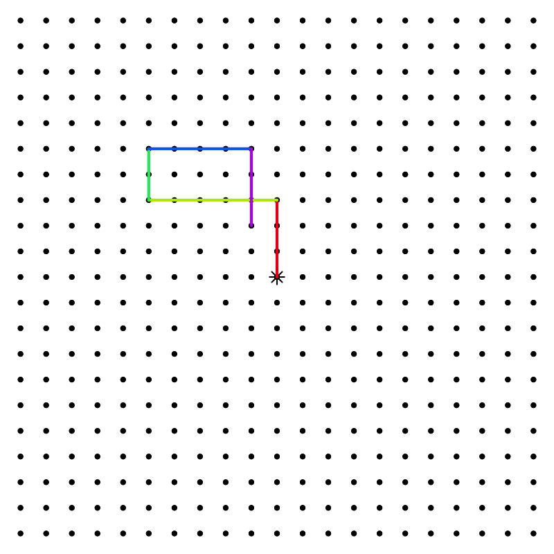

Describe the path taken by the turtle.

- North 3
- West 5
- North 2
- East 4
- South 3

A turtle starts at the star in the middle. By dragging markers along a grid, she makes 5 line segments. The first segment is red, and then she changes color after each turn, following the progression of a rainbow.

The distance between adjacent dots is 1 unit. The grid is oriented with North pointing up and East pointing right.

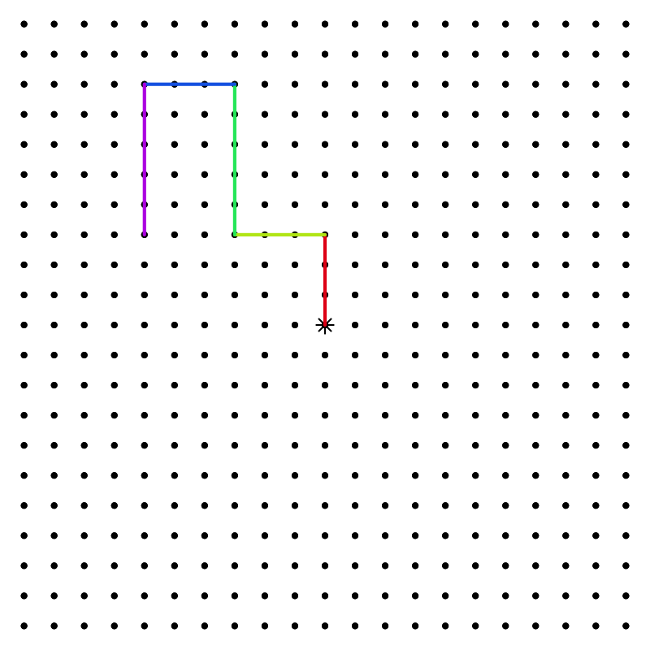

Describe the path taken by the turtle.

- North 3
- West 3
- North 5
- West 3
- South 5

A turtle starts at the star in the middle. By dragging markers along a grid, she makes 5 line segments. The first segment is red, and then she changes color after each turn, following the progression of a rainbow.

The distance between adjacent dots is 1 unit. The grid is oriented with North pointing up and East pointing right.

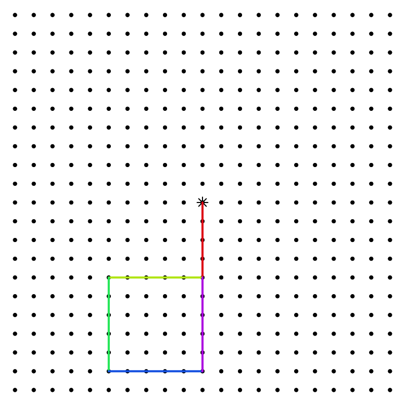

Describe the path taken by the turtle.

- South 4
- West 5
- South 5
- East 5
- North 5

A turtle starts at the star in the middle. By dragging markers along a grid, she makes 5 line segments. The first segment is red, and then she changes color after each turn, following the progression of a rainbow.

The distance between adjacent dots is 1 unit. The grid is oriented with North pointing up and East pointing right.

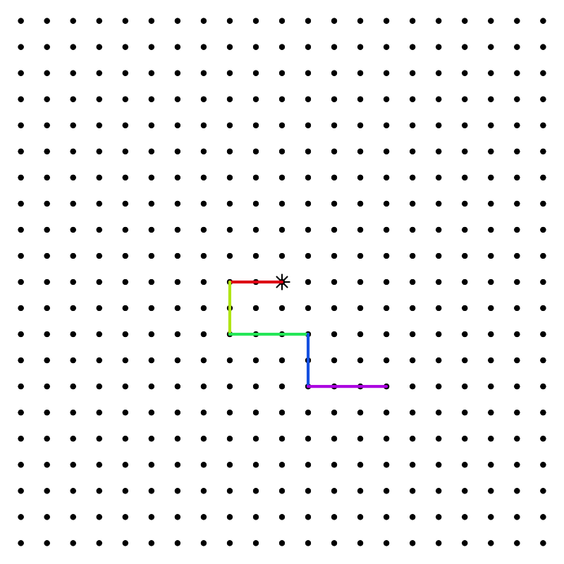

Describe the path taken by the turtle.

- West 2
- South 2
- East 3
- South 2
- East 3

A turtle starts at the star in the middle. By dragging markers along a grid, she makes 5 line segments. The first segment is red, and then she changes color after each turn, following the progression of a rainbow.

The distance between adjacent dots is 1 unit. The grid is oriented with North pointing up and East pointing right.

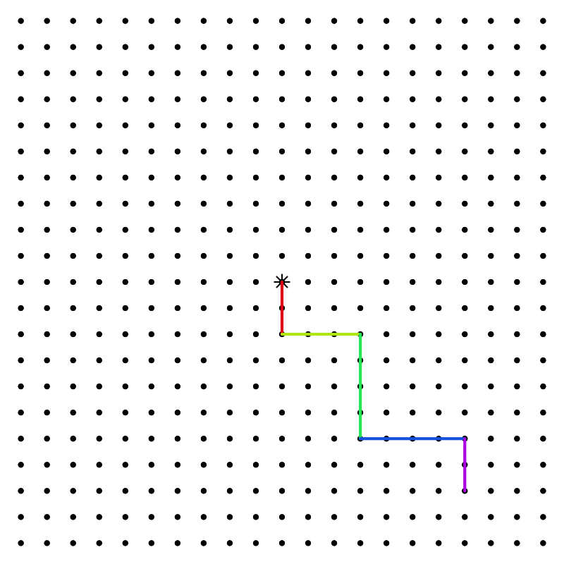

Describe the path taken by the turtle.

- South 2
- East 3
- South 4
- East 4
- South 2

A turtle starts at the star in the middle. By dragging markers along a grid, she makes 5 line segments. The first segment is red, and then she changes color after each turn, following the progression of a rainbow.

The distance between adjacent dots is 1 unit. The grid is oriented with North pointing up and East pointing right.

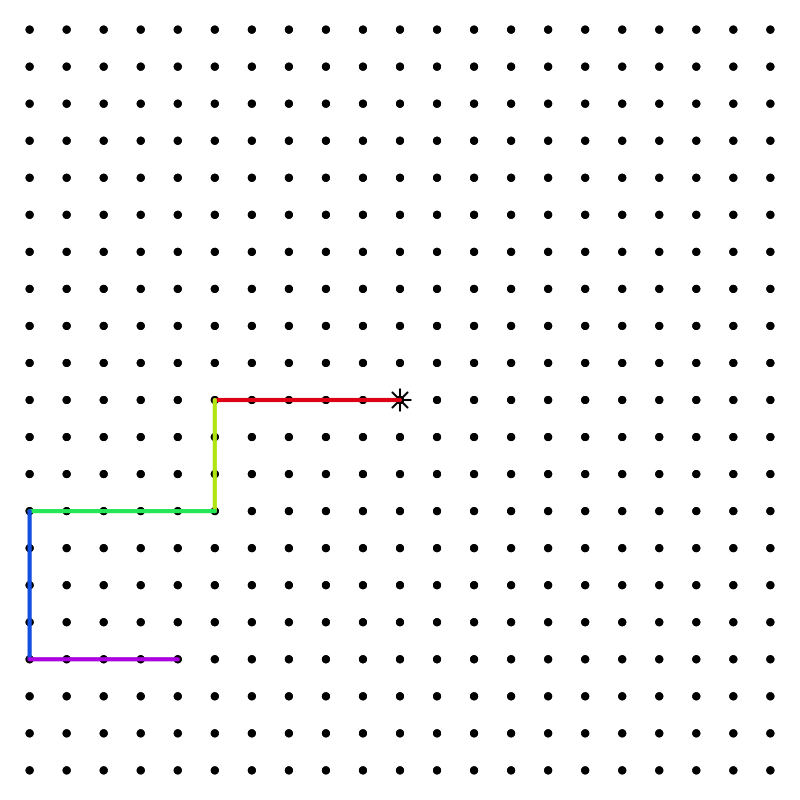

Describe the path taken by the turtle.

- West 5
- South 3
- West 5
- South 4
- East 4

A turtle starts at the star in the middle. By dragging markers along a grid, she makes 5 line segments. The first segment is red, and then she changes color after each turn, following the progression of a rainbow.

The distance between adjacent dots is 1 unit. The grid is oriented with North pointing up and East pointing right.

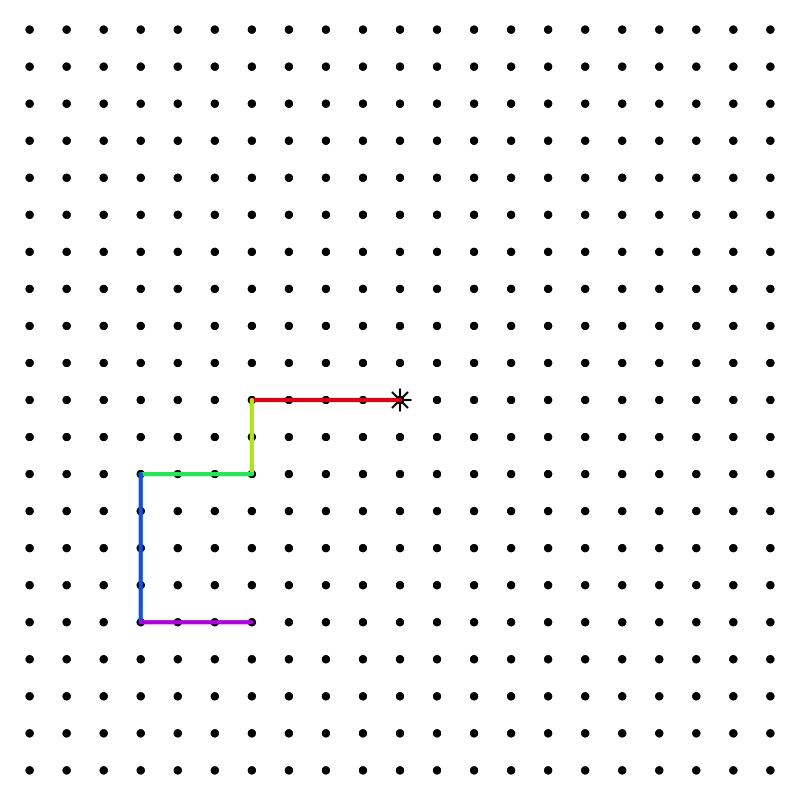

Describe the path taken by the turtle.

- West 4
- South 2
- West 3
- South 4
- East 3